# Toolbox-H1B Visa Petitions

Chang Ai

# Backgroud

For international students to get the H1B visa is one of the main concerns going into the US. job market. It became a big question how the H1B visa process will change after Donald Trump’s executive order tightening rules on H1B visa program.

In this presentation, I will explore the H1b visa petitions data from 2011-2016. Assuming international students don’t have strong preferences besides getting an H1B visa, my goal is to help international students target the right positions, employers, locations, etc.

# Data Pre-processing

Let’s take a look at the data structure:

```
## # A tibble: 6 x 11
##      X1         CASE_STATUS
##   <int>               <chr>
## 1     1 CERTIFIED-WITHDRAWN
## 2     2 CERTIFIED-WITHDRAWN
## 3     3 CERTIFIED-WITHDRAWN
## 4     4 CERTIFIED-WITHDRAWN
## 5     5           WITHDRAWN
## 6     6 CERTIFIED-WITHDRAWN
## # ... with 9 more variables: EMPLOYER_NAME <chr>, SOC_NAME <chr>,
## #   JOB_TITLE <chr>, FULL_TIME_POSITION <chr>, PREVAILING_WAGE <dbl>,
## #   YEAR <int>, WORKSITE <chr>, lon <dbl>, lat <dbl>
```

Convert variables to factors and rename levels in case status.

# Status

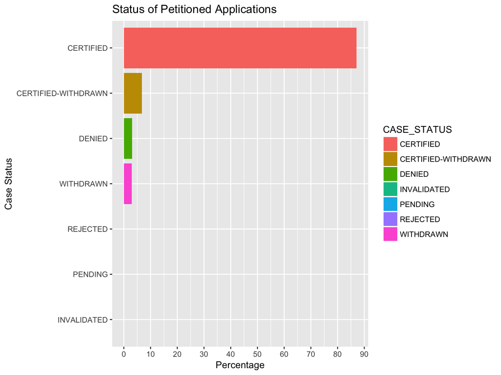

The majority of the petitioned applicants are certified. Thus further analysis will focus on certified petitions.

# Top 50 Employers

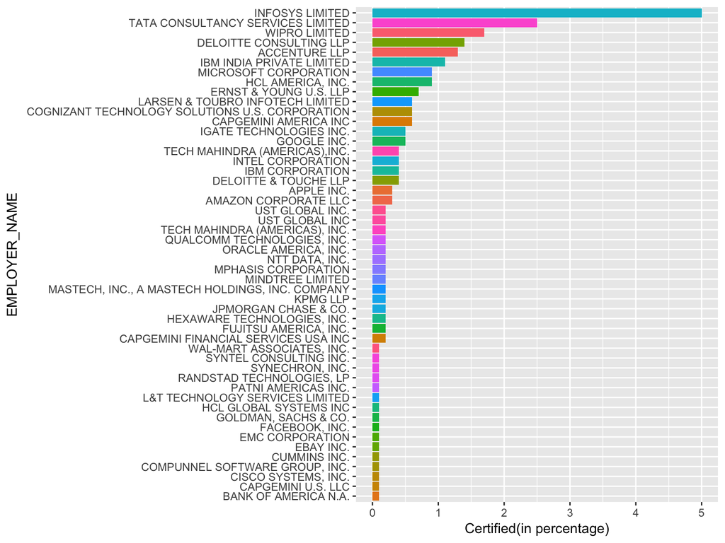

# Top 50 Locations

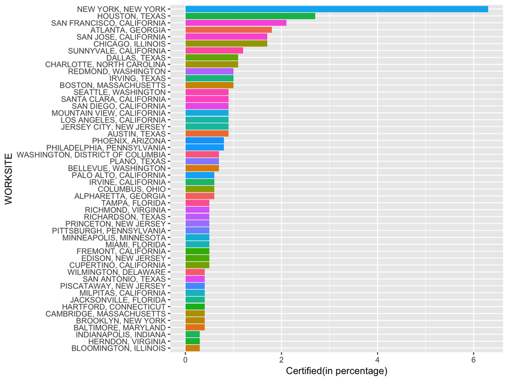

# Average Wage thoughout the time

```
##      Min.   1st Qu.    Median      Mean   3rd Qu.      Max.
##     10500     54770     65120     72550     81430 306000000
```

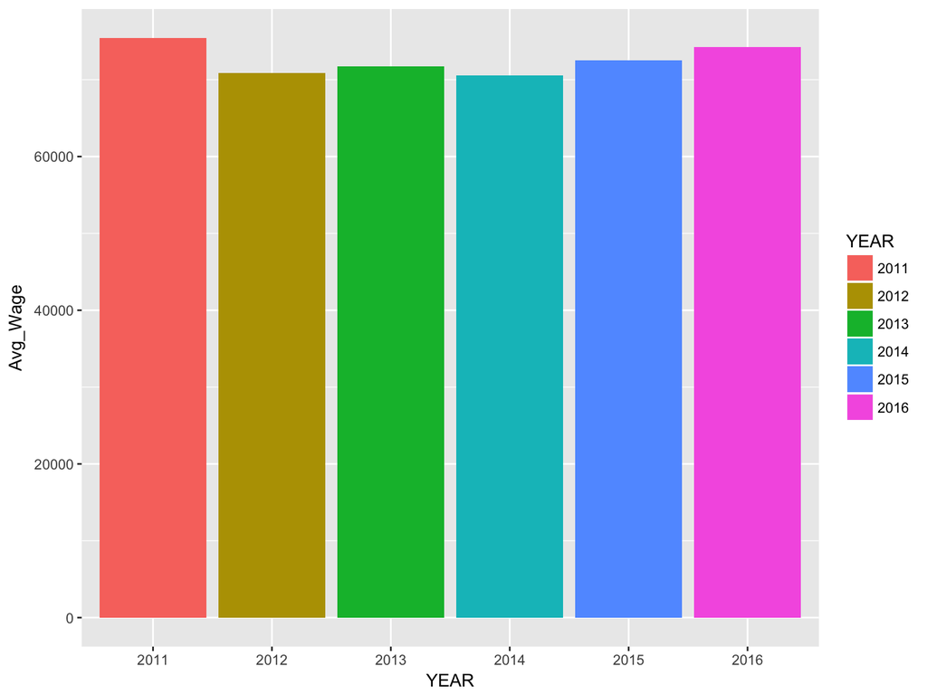

# Conclusion

The average wage from 2011-2016 is far below the minimum requirement of $130,000 in Trump’s H1B visa reform bill. With the increasing uncertainty in the H1B visa process, international students can target the top 30 employers and locations across the US. Besides being open minded with locations and employers, job hunters should also explore other opportunities outside of US.